# Figaro Methane Sensor Calibration

Tuba Bucak Onay

2025-02-11

## CH<sub>4</sub> sensor calibration Facts

TGS sensor operates on the principle of chemical adsorption and desorption of gases on sensor’s surface. Some gases- for example water vapor- can interfere voltage measurements by causing a decrease in resistance of the sensor as the water vapor is adsorbed on the sensor surface which requires the calibration necessary.

Based on the sensor’s circuit diagram, the sensing area is connected in series with the reference resistor (RL). The circuit voltage (RL) is 5V, which is distributed across both the sensing area and the reference resistor. However, the voltage across the reference resistor changes with the concentration of gas. When the target gas is detected, the resistance of the sensing area drops, causing the measured voltage (VL) to rise.

$$R_s = \left(\frac{V_c}{V_L} -
1\right)$$

Since the surface characteristics and resistance of individual sensors vary, each sensor requires calibration. This calibration must also consider temperature and humidity, as sensor voltage is significantly affected by water vapor. Ideally, this calibration should be performed in dry air free from volatile compounds, although achieving such conditions can be challenging. Eugster and Kling (2012) proposed an alternative methodology that allows for calculating the relative sensor response $\left(\frac{R_s}{R_o}\right)$ without knowing the exact value of the resistance in the background atmospheric levels.

$$\frac{R_s}{R_o} =
\frac{\left(\frac{V_c}{V_L}-
1\right)}{\left(\frac{V_c}{V_0}-1\right)}$$

During the calibration of each sensor, we adopted the approach described in Bastviken et al. (2020). To calculate the relative sensor response $\frac{R_s}{R_o}$, we needed to determine Vo for each reference measurement (the baseline voltage for the given humidity level). Since humidity and voltage are highly linearly correlated, we used a linear model.  
This step is performed with atmospheric methane concentrations (~2 ppm) under different humidity and temperature conditions. **We place the chambers in a cold room, which gradually decreases the temperature and humidity. This allows us to take measurements at various humidity levels, enabling us to establish a relationship between sensor voltage and humidity under baseline conditions.**

$$V_o = g * H_2O_{ppm}+ P$$

**The calculated V_o is then used to determine the relative sensor response ($\frac{R_s}{R_o}$) for each measurement. Using the formula below, the calibration parameters will be found through nonlinear least squares parameter estimation.**

$$CH_4 = a* \left(\frac{R_s}{R_0}\right)^b
+ c* H_2O{ppm}*\left(\frac{R_s}{R_o}\right)^b + K$$
where CH_4 is the reference measurement (in ppm), a,b,c,K are the fitted parameter estimates. Using these fitted parameters, we will convert milivolt to ppm afterwards.

**Ideally, we should have 20-30 reference measurements ranging from 2 ppm to 200 ppm at different temperatures. We conduct this step in both a cold room and at room temperature, then check the calibration results.** If the results are not satisfactory, we add additional samples from different temperatures.

## Calibration Data Processing

#### Load necessary libraries

```r
library(lubridate)
library(tidyverse)
library(zoo)
```

#### Function for reading all the files in SD_card folder

```r
SD_read <- function(path){

  dataset<- data.frame()
  file_list <- list.files(path, full.names = TRUE)
  for (file in file_list){

    # if the merged dataset doesn't exist, create it
    if (!exists("dataset")){
      dataset <- read.csv(file, header=FALSE)
    }

    # if the merged dataset does exist, append to it
    if (exists("dataset")){
      temp_dataset <-read.csv(file, header=FALSE)
      dataset<-rbind(dataset, temp_dataset)
      rm(temp_dataset)
    }
  }

  dataset_sd <- dataset

  return(dataset_sd)
}
```

This section includes the functions will be used in calibration and following calculations. The script is adapted from Bastviken (2020)

```r
###### Calc Humidity - from Humidity_Conversion_Formulas_B210973EN-F by Vaisala / W. Wagner and A. Pruß:" The IAPWS Formulation 1995 for the Thermodynamic Properties of Ordinary Water Substance for General and Scientific Use ", Journal of Physical and Chemical Reference Data, June 2002 ,Volume 31, Issue 2, pp. 387535.

calculate_H2Oppm <- function(data, Sensor_Temp_col, Humidity_col, Pressure_col){
  A = 6.116441 # A, m, Tn aproximated empirical coefficients for calculating RH.
  m = 7.591386
  Tn = 240.7263
  Pws <- A * 10**((m * data[[Sensor_Temp_col]]) / (data[[Sensor_Temp_col]] + Tn))
  Pw <- data[[Humidity_col]] * Pws / 100
  data$H2Oppm <- Pw * 10**6 / data[[Pressure_col]]
  return(data)
}


#### Fitting Vo ~ Humidity

nlr <- function(Xvar, g, P){

  return(g*Xvar + P)
}


# The function fits a model to estimate the parameter for Vo ~ Humidity,
# assuming that the air should have more or less stable CH4, and any differences in the voltage are
# attributed to humidity.

fitVo <- function(data_air, ch4_mV, humidity){

  # Extract the methane voltage and humidity data from the input data frame
  Vout <- data_air[,ch4_mV]
  Xvar = data_air[,humidity]

  # Fit the model using the nls function and a nonlinear least squares regression method
  # to estimate the parameters for Vo ~ Humidity
  m <- nls(Vout ~ nlr(Xvar, g, P), start = list(g=1, P=1))

  # Plot the data and the model fit
  plot(Xvar, Vout, col.lab = "darkgreen", col.axis = "darkgreen", xlab = "Humidity", ylab = "Vout")
  lines(Xvar, predict(m))

  # Use the model fit to predict the methane voltage
  modVout <- predict(m)

  # Calculate the ratio of predicted and observed methane voltage
  fCH4 <- modVout/Vout

  # Calculate the residuals between the predicted and observed methane voltage
  res <- Vout - modVout

  # Calculate the root-mean-square error (RMSE) of the predicted methane voltage
  VoRMSE <- sqrt(mean((Vout - modVout)^2))

  # Extract the estimated parameters for Vo ~ Humidity
  gP <- coefficients(m)

  # Store the results in a list and give them descriptive names
  Vo_results <- list(modVout, fCH4, res, VoRMSE, gP)
  names(Vo_results) <- c("modVout", "fCH4", "res", "VoRMSE", "gP")

  # Return the results list
  return(Vo_results)
}



#### calculate the relative sensor response R = Rs/Ro TO CH4

#SENSOR corrections:
#Based on product information informaion for NGM2611-E13 and TGS2611:
#Vc = total circuit voltage = 5.0 ±0.2 V
#VH = heater voltage (same as Vc)
#Vout = V = measurement output voltage. Depend on Rs.
#V0 = Vout at reference level of CH4, H2O and temperature (ideally zero gas influence and only related with RL)
#RL = resistor in serie with sensor; can vary among sensors
#Rs = resistance in sensor; affected by gas(es)
#R0 = background reference resistance. Ideally same as RL, but in practice based on V0.
#Rs/R0 related to CH4 conc.
#Rs = ((Vc-V)/V)*RL = (Vc/V – 1)*RL
#R0 = (Vc/V0 – 1)*RL
#Rs/R0 = (Vc/V – 1) / (Vc/V0 – 1)

# For each VL, use H2Oppm to derrive Vref=VL0 = VL at reference gas concentration from df_ghv. Then calculate Rs/R0 ratio


calculate_Rs_Ro <- function(data, g, P, H2Oppm_col, CH4_1_col){
  Vc=5000
  # calculate Vok using humidity~ Vo relationship
  data$Vok <- g * data[[H2Oppm_col]] + P

  # calculate Rs/Ro
  data$Rs_Ro <- (Vc / data[[CH4_1_col]] - 1) / (Vc / data$Vok - 1)
  # return modified data frame
  return(data)
}


###### USING ALL DATA for final curve fit equation...#######################

# A function that defines the nonlinear function used in the calibration model
func_CH4 <- function(xdata,a,b,c,K, R_column, H2Oppm){
  return (a*(xdata[,R_column]**b) + c*(a*(xdata[,R_column]**b))*xdata[,H2Oppm] + K)
}


# A function to calibrate CH4 using nonlinear regression and calculate error metrics.
calibrate_CH4 <- function(Dfinal, initial_params, R_column, H2Oppm, CH4ppm)  {

  # Extracting predictor and response variables from the data
  xdata = Dfinal[, c(R_column,H2Oppm)]
  ydata = Dfinal[, CH4ppm]

  # Fitting a nonlinear regression model to the data using starting parameter values and control parameters
  # The nonlinear function used is func() with parameters a, b, c, K, R_column, and H2Oppm
  rs_ch4_model <- nls(ydata~ func_CH4(xdata, a, b, c, K, R_column, H2Oppm),
                      start = initial_params, control = list(maxiter = 500))

  # Predicting CH4 concentrations using the fitted model
  modCH4k <- predict(rs_ch4_model)
  Coeffs <- coefficients(rs_ch4_model)

  # Calculating the root mean squared error between predicted and actual CH4 concentrations
  VoRMSE_CH4 <- sqrt(mean((ydata - modCH4k)^2))

  # Calculating R-squared between predicted and actual CH4 concentrations
  R2 <-cor(modCH4k, ydata)^2

  # Storing the results in a list
  results <- list(modCH4k= modCH4k,
                  Coeffs= Coeffs, VoRMSE_CH4= VoRMSE_CH4, R2 = R2 )

  # Setting up a two-panel plot for visualizing the calibration results
  par(mfrow = c(1, 2))

  # Plotting measured CH4 concentrations against Rs/Ro ratios
  plot(xdata[,R_column],
       ydata, xlab = "Rs/Ro", ylab = "CH4 (ppm)", pch=20, col="blue")

  # Plotting predicted CH4 concentrations against measured CH4 concentrations
  plot(ydata, modCH4k,
       xlab = "CH4 (ppm) measured", ylab = "CH4 (ppm) predicted", pch=20, col="blue")

  # Adding a linear regression line to the second plot
  abline(lm(modCH4k ~ ydata))

  # Returning the results
  return(results)
}
```

## Loading and Preparing LGR Reference Data

To calibrate the Figaro methane sensor, we use reference data from the LGR instrument. The LGR provides high-frequency methane concentration measurements, but for calibration, we extract only the **stable peak concentrations** after each methane injection.

Here, we load the LGR data from **two different days (May 16 and May 17)** and process it for further analysis. The important issue here is to check the time difference between LGR and low cost GHG system before matching the data.

```r
#setwd('set your working directory')

# In this example we had calibration data from 2 different days.

LGR_May_16<- read.csv("LGR_May_16.csv")

LGR_May_17<- read.csv("LGR_May_17.csv")


# We need to change the format of the datetime / Please check your datetime format. Because of different settings of computers and Microsoft office, you may need to use other functions like ymd_hms or dmy_hms...

LGR_May_16$DateTime <- mdy_hms(LGR_May_16$DateTime)

LGR_May_17$DateTime <- mdy_hms(LGR_May_17$DateTime)

# Convert to unix time - somehow I had some problems when I work with datetime. It s always good to have numeric time format.
LGR_May_16$Unix <- as.numeric(LGR_May_16$DateTime)
LGR_May_17$Unix <- as.numeric(LGR_May_17$DateTime)


# Correct for the time difference between the LGR and Figaro sensor
# The real-time clock of the Arduino has a 53-second offset

LGR_May_16$UnixCH<- LGR_May_16$Unix -53
LGR_May_17$UnixCH<- LGR_May_17$Unix -53


# Combine the data from both days into a single dataset

LGR_May<- bind_rows(LGR_May_16, LGR_May_17)
```

## Loading and Preparing Low-cost Sensor Data

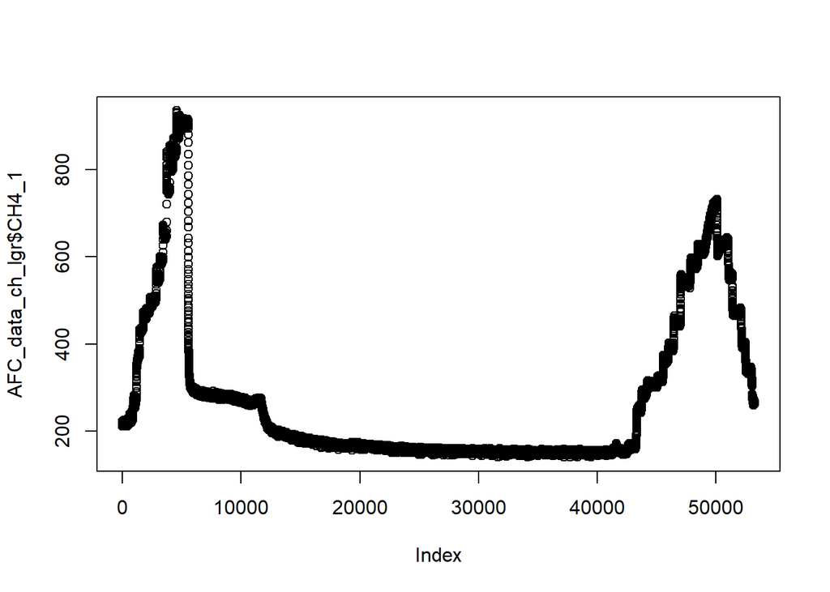

```r
# Loading all the calibration data in the folder.
AFC_data<- SD_read("AFC_data")

# Since the data has no headings, we are naming the columns.
colnames(AFC_data)<- c( "Stage","CH4_1", "CH4_2", "CO2", "Temp", "Humidity", "Extra", "Pressure", "Date")

# We didnt have pressure measurements and we assume it as this.
AFC_data$Pressure <- 1013

# Convert DateTime to POSIX format for time-based operations
# Check the format to ensure compatibility across systems
AFC_data$Date<- dmy_hms(AFC_data$Date)


# We are calculating absolute humidity (H2Oppm) using Temperature, Relative Humidity and Pressure
AFC_data<- calculate_H2Oppm(data = AFC_data,
                     Sensor_Temp_col = "Temp",
                     Humidity_col = "Humidity",
                     Pressure_col = "Pressure")


#Convert to unix time
AFC_data$Unix <- as.numeric(AFC_data$Date)



# Define a function to find the closest Unix time to match LGR data with low-cost system
find_closest_time <- function(x, times) {
  closest_time_index <- which.min(abs(times - x))
  return(times[closest_time_index])
}


# Apply the function to each unix time value in df2
AFC_data$closest_time <- apply(AFC_data["Unix"], 1, find_closest_time, times = LGR_May$UnixCH)


# Merge the two data frames based on the closest unix time value
AFC_data_ch_lgr <- merge(AFC_data, LGR_May, by.y = "UnixCH", by.x = "closest_time", all.y = TRUE)

AFC_data_ch_lgr$diff <- AFC_data_ch_lgr$Unix.x- AFC_data_ch_lgr$closest_time


# This difference threshold could change. In this data I found the right balance in 2.4 because the measurement interval is 2-3 seconds.
AFC_data_ch_lgr<- AFC_data_ch_lgr %>%
  mutate(LGR = ifelse((diff <= 2.4 & diff > 0), CH4_ppm, NA))


# I just want to check how the data looks like
plot(AFC_data_ch_lgr$CH4_1)
```

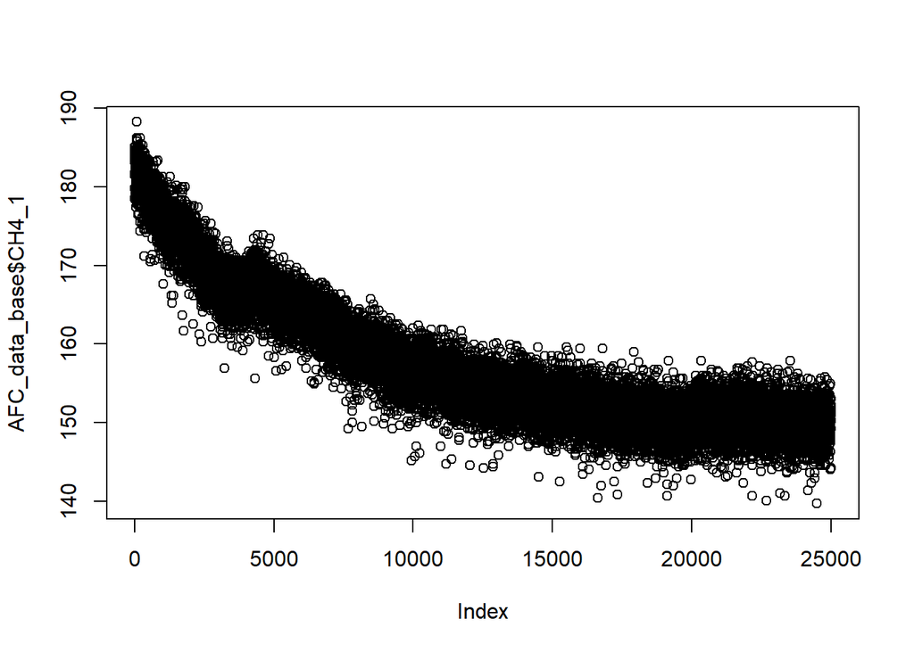

```r
# We should extract the periods with baseline concentrations .- you can filter by time if you know the exact times, or you do it roughly by exploring the plot like what I did here

AFC_data_base <- AFC_data_ch_lgr[c(15000:40000),]

# We expect linear relationship betwewn CH4_1 and H2Oppm in baseline CH4 concentrations.
plot(AFC_data_base$CH4_1)
```

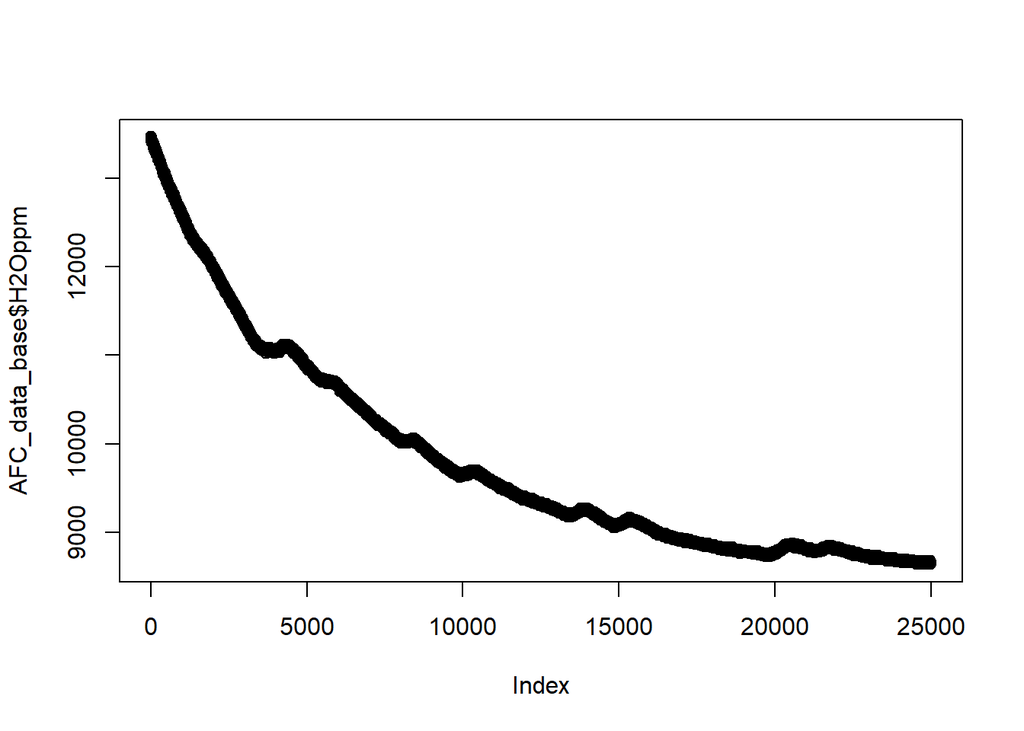

```r
plot(AFC_data_base$H2Oppm)
```

```r
# Rolling mean to decrease the noise
AFC_data_base$MedCH4 <- rollmean(AFC_data_base$CH4_1, k= 10, fill="extend")
AFC_data_base$MedH2O <- rollmean(AFC_data_base$H2Oppm, k= 10, fill="extend")

# Assign baseline measured values to a separate column
AFC_data_base$LGR <- 2.05


# In curve fitting, it will be nice to have extra samples from baseline. So I just did random sampling from the baseline measurement.
AFC_data_ch_lgr_extra<- AFC_data_base%>%
sample_n(6)
```

## Fitting Linear Model for estimating baseline voltage for different humidity levels which later will be used for calibration

```r
AFC_data_1_fitV0<- fitVo(AFC_data_base, "MedCH4", "MedH2O")
```

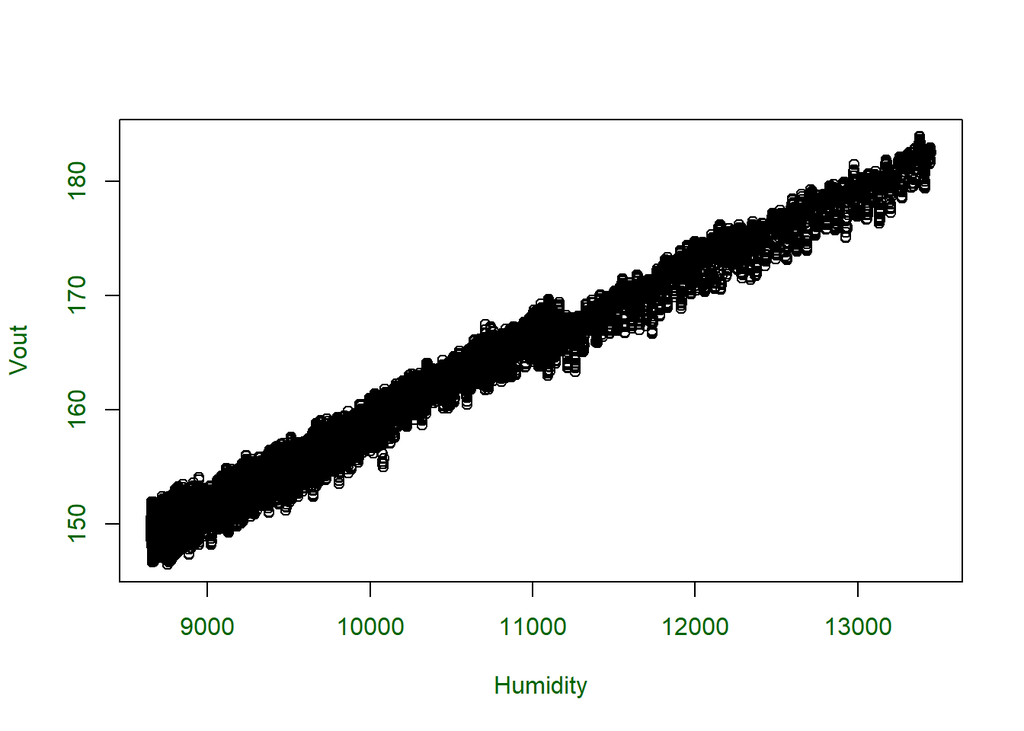

```r
# Extract the coefficients - which will be used later for voltage to ppm conversion
g <- AFC_data_1_fitV0$gP['g']
P <- AFC_data_1_fitV0$gP['P']

# Remove the non-complete rows.
complete_rows <- complete.cases(AFC_data_ch_lgr$LGR)


#Index of the nonNA rows based on LGR results column
non_na_rows <- which(complete_rows & !is.na(AFC_data_ch_lgr$LGR))


AFC_data_ch_lgr$Date <- ymd_hms(AFC_data_ch_lgr$Date)

AFC_data_ch_lgr$Date <- AFC_data_ch_lgr$Date
med_ch4_values <- numeric()
med_H2O_values <- numeric()

# Instead of extracting one data point I used the average of last two minutes

for (i in non_na_rows) {
#  print(i)
  x_datetime <- AFC_data_ch_lgr$Date[i]
  x_datetime_range <- c(x_datetime - seconds(120), x_datetime)
  med_ch4 <- AFC_data_ch_lgr %>%
    filter(Date >= x_datetime_range[1] & Date <= x_datetime_range[2] & !is.na(CH4_1)) %>%
    summarize(median(CH4_1, na.rm = TRUE))
  med_ch4_values[i] <- med_ch4
    med_H2O <- AFC_data_ch_lgr %>%
    filter(Date >= x_datetime_range[1] & Date <= x_datetime_range[2] & !is.na(H2Oppm)) %>%
    summarize(median(H2Oppm, na.rm = TRUE))
    med_H2O_values[i] <- med_H2O

}
med_ch4_values<- unlist(med_ch4_values)
med_H2O_values<- unlist(med_H2O_values)

# 4. Add the median CH4 values to the original data frame
AFC_data_ch_lgr$MedCH4 <- NA
AFC_data_ch_lgr$MedCH4[non_na_rows] <- med_ch4_values

AFC_data_ch_lgr$MedH2O <- NA
AFC_data_ch_lgr$MedH2O[non_na_rows] <- med_H2O_values

# Subset the data frame based on the non-NA rows
AFC_data_GHG_data_corrected <- AFC_data_ch_lgr[non_na_rows, ]



# Add extra data from baseline concentrations
AFC_data_GHG_data_corrected <- rbind(AFC_data_GHG_data_corrected, AFC_data_ch_lgr_extra)


# Calculate relatıve sensor response
AFC_data_GHG_data_corrected <- calculate_Rs_Ro(data = AFC_data_GHG_data_corrected,
                                         g,
                                          P,
                                          H2Oppm_col = "MedH2O",
                                          CH4_1_col= "MedCH4")

# We need to give initial parameters. If calibrate_CH4 does not converge, we have to play with the initial params or
initial_params <- list(a= -1 , b=-3 , c= 0.0001 , K=1)



# Remove some of the unstable observations during calibration

# AFC_data_GHG_data_corrected<- AFC_data_GHG_data_corrected[c(-24:-26),]


calibrated_AFC_data<- calibrate_CH4(AFC_data_GHG_data_corrected, initial_params, "Rs_Ro", "MedH2O", "LGR")
```

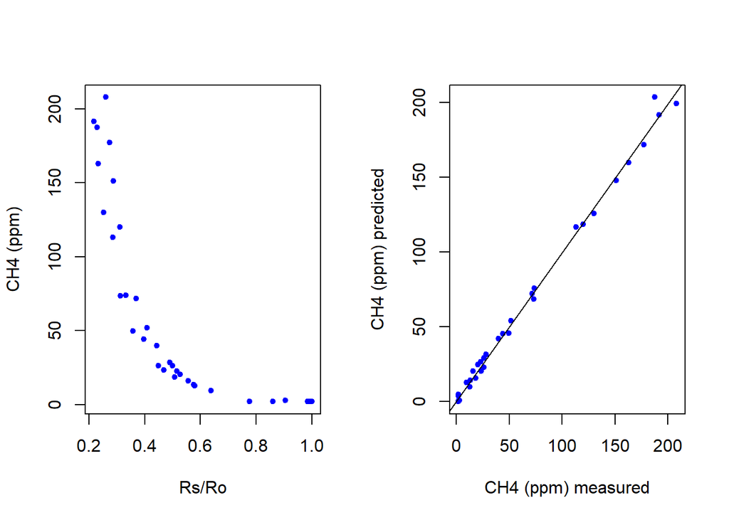

```r
# plot(AFC_data_GHG_data_corrected$Rs_Ro, AFC_data_GHG_data_corrected$CH4_ppm)


# Print the calibration coefficients - we will use them later
print(paste('g:', g))
```

```
## [1] "g: 0.00695650209819654"
```

```r
print(paste('P:', P))
```

```
## [1] "P: 89.2810698259999"
```

```r
# the order is a,b,c,K
print(paste(calibrated_AFC_data$Coeffs))
```

```
## [1] "1.78415770789791"     "-2.77637901644084"    "6.65671636289167e-05"
## [4] "-2.71703144092577"
```